# PA 4: Governement Spending

Tidy Data with tidyr & Factor Ordering in Visualizations with forcats

```r
# load packages
library(readxl)
library(tidyverse)
```

Today you will be tidying untidy data to explore the relationship between countries of the world and military spending.

Download starter .qmd file

Download data – `gov_spending_per_capita.xlsx`

## Data Description

The SIPRI (Stockholm International Peace Research Institute) Military Expenditure Database is an open source data set which contains consistent time series on the military spending of countries for the period 1949–2019. The database is updated annually, which may include updates to data for any of the years included in the database.

Military expenditure in local currency at current prices is presented according to both the financial year of each country and according to calendar year, calculated on the assumption that, where financial years do not correspond to calendar years, spending is distributed evenly through the year. Figures in constant (2017) and current US $, as a share of GDP and per capita are presented according to calendar year. The availability of data varies considerably by country, but for a majority of countries that were independent at the time, data is available from at least the late 1950s. Estimates for regional military expenditure have been extended backwards depending on availability of data for countries in the region, but no estimates for total world military expenditure are available before 1988 due to the lack of data for the Soviet Union.

SIPRI military expenditure data is based on open sources only.

## Data Import

First, you should notice that there are ten different sheets included in the data set. We are interested in the sheet labeled *“Share of Govt. spending”* which contains information about the share of government spending that is allocated to military spending.

Next, you’ll notice that there are notes about the data set in the first six rows. Ugh! Also notice that the last six rows are footnotes about the data set. **Ugh**!

Rather than copying this one sheet into a new Excel file and deleting the first and last six rows, let’s learn something new about the `read_xlsx()` function!

**Data Import with `read_xlsx()`**

The `read_xlsx()` function has a `sheet` argument, where you specify the name of the sheet that you want to use. The name must be passed in as a string (in quotations)!

The `read_xlsx()` function also has a `skip` argument, where you specify the number of rows you want to be skipped *before* reading in the data.

Finally, `read_xlsx()` also has a `n_max` argument, where you specify the maximum number of rows of data to read in.

**1. Modify the code below to read the military expenditures data into your work space.**

**Warning**

If you have the excel file open on your computer while trying to import the data, you may get an error. Close the excel file and try running your code again.

```r
military <- read_xlsx(here::here("practice-activities",
                                 "data",
                                 "gov_spending_per_capita.xlsx"
                                 ),
                      sheet = ,
                      skip  = ,
                      n_max =
                      )
```

## Data Cleaning

In addition to `NA`s, missing or unavailable values were coded two ways.

**2. Find these two methods and write the code to replace these values with NAs. Save the mutated data set into a new object named `military_clean`.**

**Tip**

The information in the top 6 rows of the excel sheet will help you answer this question.

Helpful functions: `mutate()`, `across()` – you will need two of these, `na_if()`

**Note:** When referring to one of the year variable names, you must put tick marks (above the tab key) around the name because starting the name of a variable with a number is not commonly read as a variable name – e.g., `` `1988`:`2019` ``.

```r
# Code for completing Q2
```

Because of the use of characters to mark missing values, all of the columns 1988 through 2019 were read in as characters.

**3. Mutate these columns to all be numeric data types, instead of a character data type. Save these changes into an updated version of `military_clean`.**

```r
# Code for Q3
```

If you give the `Country` column a look, you’ll see there are names of continents **and** regions included. These names are only included to make it simpler to find countries, as they contain no data.

Luckily for us, these region names were also stored in the *“Regional totals”* sheet. We can use the `Region` column of this data set to filter out the names we don’t want.

Run the code below to read in the *“Regional totals”* data set, making any necessary modifications to the file path.

```r
cont_region <- read_xlsx(here::here("practice-activities",
                                    "data",
                                    "gov_spending_per_capita.xlsx"),
                      sheet = "Regional totals",
                      skip = 14) |>
  filter(Region != "World total (including Iraq)",
         Region != "World total (excluding Iraq)")
```

If you think about `filter()`ing data, so that only certain values of a variable are retained, we should remember our friendly `%in%` function! However, if you think about the code below, you should notice that this code retains only the values we wanted to remove!

```r
military_clean |>
  filter(Country %in% cont_region$Region)
```

[output not shown]

Unfortunately, R doesn’t come with a built-in `!%in%` function. However, a clever way to filter out observations you don’t want is with a join. A tool tailored just for this scenario is the `anti_join()` function. This function will return all of the rows of one data set **without** a match in another data set.

**4. Use the `anti_join()` function to filter out the `Country` values we don’t want in the `military_clean` data set. The `by` argument needs to be filled with the name(s) of the variables that the two data sets should be joined with.**

**Tip**

To join by different variables on `datasetX` and `datasetY`, use a named vector. For example, `by = join_by(a == b)` will match `datasetX$a` to `datasetY$b`.

```r
# Code for Q4
```

## Data Organization

The comparison I am interested in looking at is the military expenditures between Countries in Eastern Europe. Something like this:

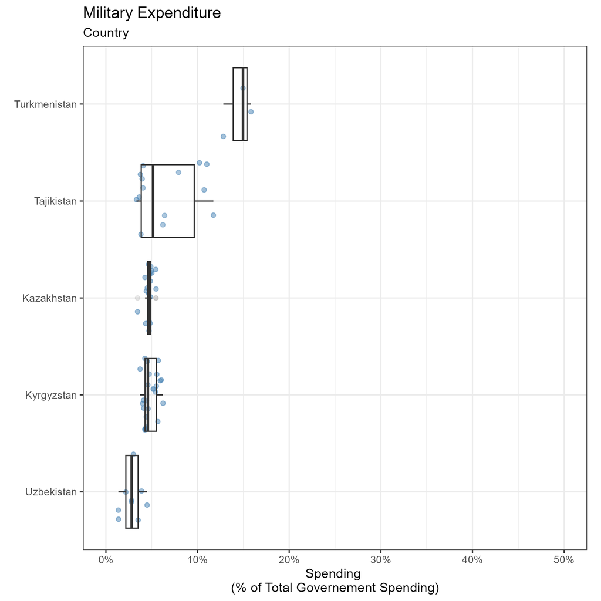

Desired plot: Countries from Central Asia used for demonstration – your plot will have different countries and spending values.

**Warning**

Unfortunately, if we want a point representing the spending for every country and year, this requires that every year is included in one column!

To tidy a data set like this, we need to pivot the columns of years from wide format to long format. To do this process we need three arguments:

- `cols` The set of columns that represent values, not variables. In these data, those are all the columns from `1988` to `2019`.
- `names_to` The name of the variable that should be created to move these columns into. In these data, this could be `"Year"`.
- `values_to` The name of the variable that should be created to move these column’s values into. In these data, this could be labeled `"Spending"`.

Each of these pieces form the three required arguments to the `pivot_longer()` function.

**5. Pivot the cleaned up `military` data set to a “longer” orientation. Save this new “long” version as a new data set called `military_long`.**

**Caution**

**Do not** overwrite your cleaned up data set. Think about code organization.

```r
# Code for Q6
```

**6. Notice that when you pivoted the data set, the `Year` variable is a character data type. Convert this to numeric.**

```r
summary(military_long)
```

[output not shown]

```r
# insert code for converting Year to numeric -- make sure to save this change to military long
```

## Data Visualization Exploration

**7. Create a plot to explore the military spending between the Eastern European Countries**

```r
# I have provided a list of the countries in Eastern Europe (in this data set) for you to use.
eastern_europe <- c("Armenia", "Azerbaijan", "Belarus",
                    "Georgia", "Moldova", "Russia", "Ukraine"
                    )

# code for plot
```

**8. Modify your code above to order the countries from largest to smallest *median* military expenditure spending.**

**Tip**

Look at the function options from the `forcats` cheatsheet.

**Canvas Submission**

**9. Looking at the plot you created above, which Eastern European country had the second highest median military expenditure?**